# act_report

#### After the wrangling of the data, I proceeded to answer three questions:

### From which source did people majorly send the tweet about their dogs?

### Which is the most popular tweet?

### Which dog breed has the highest average rating?

#### The following bar chart depicts the shares of each source of tweet.

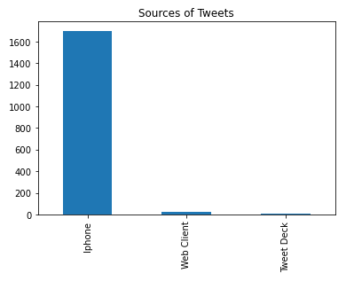

#### The Iphone had 98.2% of the tweet as against the 1.3% for Web Client and 0.5% for Tweet Deck

### Which is the most popular tweet?

#### The most popular tweet is the tweet with the most engagement. Engagement is a measure of interactions other users make with the tweet and this was determined by adding the number of likes a tweet had to the number retweets the tweet generated.

#### From the analysis, it was discovered that the tweet with id:744234799360020481 was able to gather 79515 retweets and 131075 likes, totalling 210590 engagement which was the highest, making the tweet the most popular.

### Which dog breed has the highest average rating?

#### After selecting the p1 column as the most correct result of the image analysis due to it having the highest accuracy of the three possible results, the average of the numerator for each dog breed group was calculated and sorted in descending order according to the mean of the rating.

#### It was discovered that the Saluki dog breed had the highest average rating.